# Part I - (Students Performance Exploratory Analysis )

## Univariate Exploration

### First, let's notice the trends in the distrbution of all variables of interest...

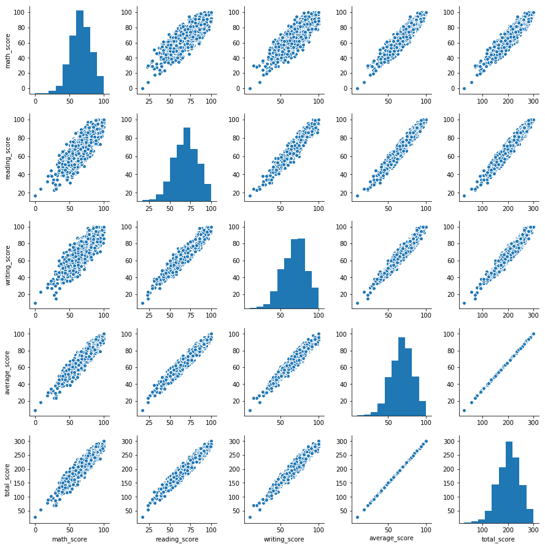

```python
sb.pairplot(df);
```

#### Let's take a look at the distrbution of students performance in each subject

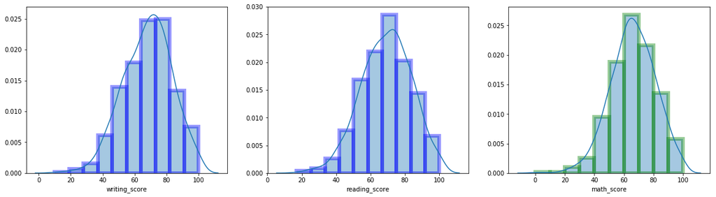

```python
# plot the figures
fig, (ax1, ax2, ax3) = plt.subplots(1, 3, figsize=(20, 5))

# plot the graphs
sb.distplot(df['writing_score'], bins=10, ax=ax1, hist_kws=dict(edgecolor='blue', linewidth=6))
sb.distplot(df['reading_score'], bins=10, ax=ax2, hist_kws=dict(edgecolor='blue', linewidth=6));
sb.distplot(df['math_score'], bins=10, ax=ax3, hist_kws=dict(edgecolor='green', linewidth=6));
```

We can observe a trend of students' score peaking at 60-80 (total score obtainable is 100), but also notice that more students' scored between 40-50 in maths than in reading and writing. Seems like many of the students' are not really into maths. Let's go on and see the distribution of all scores in all subject combined-Average score.

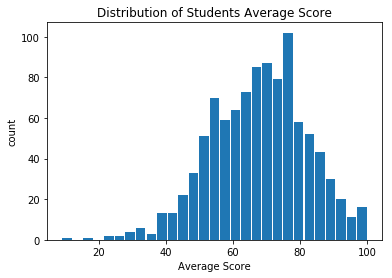

```python
data=df['average_score']
plt.hist(data, bins=29, rwidth=0.9);
plt.title('Distribution of Students Average Score')
plt.xlabel('Average Score')
plt.ylabel('count');
```

The plot above also shows the students' score peaking at around 60-80; The same trend that was observed in each individual subject.

#### I think that the type of lunch the students eat may have a great influence on their performance in the tests. First, let's take a look at the how many students had standard lunch.

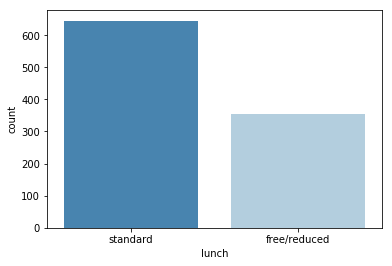

```python
sb.countplot(x='lunch', data=df, palette='Blues_r');
```

This plot reveals that most of the students infact had standard lunch, also we have established that most of the students scored between 60-80. We may be on our to discovering an interesting correlation.

### What is the highest level of education of most parents?

```python
# list of categorie sin order
education_order= ['some high school', 'high school', 'some college', "associate's degree", "bachelor's degree", "master's degree"]
race_order=['group A', 'group B', 'group C', 'group D', 'group E']
test_order=['none', 'completed']
```

```python
df['race/ethnicity']=pd.Categorical(df['race/ethnicity'], categories=race_order, ordered=True)
df['parental_level_of_education']=pd.Categorical(df['parental_level_of_education'], categories=education_order, ordered=True)
df['test_preparation_course']=pd.Categorical(df['test_preparation_course'], categories=test_order, ordered=True)
```

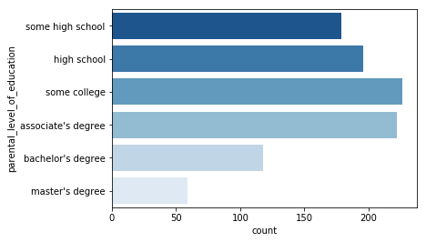

```python
sb.countplot(y='parental_level_of_education', data=df, palette='Blues_r');
```

The plot above reveals that the hightest level of education of most of the parents is 'some college', and the lowest is master's degree. Does this stat have an effect on the students' test performance? We'll find out soon enough.

### What percentage of students completed the test preparation course?

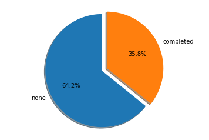

```python
sorted_counts=df['test_preparation_course'].value_counts()
plt.pie(sorted_counts, labels = sorted_counts.index, explode=(0, 0.1), startangle = 90, autopct='%1.1f%%',shadow=True);
plt.axis('equal');
```

The plot above shows that just 35.8% of the students completed the test preparation course. I wasn't expecting this result. I thought most student would have completed the test preparation course, this is because i observed that most students scored around 60-80. Is there a positive relationship between completion of the test preparation course and scores? We'll see.

#### Which gender is more?

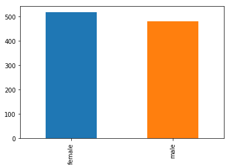

```python
df['gender'].value_counts().plot.bar();
```

The plot above shows that there are more females than males, although the difference is not so much.

### What is the race/ethnicity of most students?

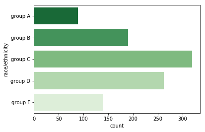

```python
sb.countplot(y='race/ethnicity', data=df, palette='Greens_r');
```

Most student are from ethnic group C, and ethnic group A has the least number of student.

### Discuss the distribution(s) of your variable(s) of interest. Were there any unusual points? Did you need to perform any transformations?

> I observed that most of the students had standard lunch which is really interesting because i suspected that the kind of lunch the students ate (standard or free/reduced) had an effect on their test performance.

### Of the features you investigated, were there any unusual distributions? Did you perform any operations on the data to tidy, adjust, or change the form of the data? If so, why did you do this?

> I noticed that the majority of students had a score within the range of 60 and 80 which is above pass mark and i thus expected that most them had completed the test preparation course, but interestingly, that's not the case.